# Divvy Cyclistic Bike-Share Case Study

Cynthia Ichalut

2025-08-29

# Background

Cyclistic, a Chicago-based bike-share company, has grown to a fleet of over 5,800 bicycles and 692 docking stations since its launch in 2016. Cyclistic stands out by offering reclining bikes, hand tricycles, and cargo bikes, making its service accessible to people with disabilities and others who can’t use a regular bike. Majority of the riders use the traditional bikes. While its marketing has historically relied on flexible pricing to attract a broad customer base, with pricing options such as single-ride passes, full-day passes, and annual memberships.Financial analysis has revealed that annual members are significantly more profitable than casual riders.

## Business Task

The primary business task is to analyze Cyclistic’s historical trip data to understand how casual riders and annual members differ in their riding habits. Through this process, data-driven insights will be used to identify trends and provide actionable recommendations, with the ultimate goal of developing a targeted marketing strategy to convert casual riders into more profitable annual members.

### Data Sources Used

- The primary data used for this analysis is Cyclistic’s historical bike trip data. Which is a public dataset containing information on trips taken by both casual riders and annual members from Jan to March in 2019 and 2020,with detailed information for each bike trip i.e ride_id, start_time, end_time, and station information.
- Due to data privacy restrictions, personally identifiable information about Cyclistic riders was inaccessible, limiting linking pass purchases to credit card numbers to determine if casual riders are repeat customers or local residents. As a result, this analysis focuses exclusively on behavioral patterns derived from the trip data to understand the differences between annual members and casual riders.

## Data Cleaning Process

The process involved:

#### 1. Loading the necessary libraries

```r
library(tidyverse)
library(lubridate)
library(janitor)
```

#### 2. Import and view the the Divvy 2019 Q1 and Divvy 2020 Q1 datasets

The primary datasets used are the Divvy 2019 Q1 and Divvy 2020 Q1 datasets.

```r
library(readr)
Divvy_2019 <- read_csv("C:/Users/PC/Downloads/Divvy_Trips/Divvy_Trips_2019_Q1 - Divvy_Trips_2019_Q1.csv")
Divvy_2020 <- read_csv("C:/Users/PC/Downloads/Divvy_Trips/Divvy_Trips_2020_Q1 - Divvy_Trips_2020_Q1.csv")
View(Divvy_2019)
View(Divvy_2020)
```

- The first data frame (Divvy_2019) contains 365,069 rows and 12 columns. It includes key information like trip duration, user type, and station IDs.
- The second data frame (Divvy_2020) contains 426,887 rows and 13 columns. It includes similar information but also contains latitude and longitude coordinates for both the start and end stations of each ride.
- They both have different column types and names.

#### 3. Renamed the columns in the 2019 dataset to match the 2020 dataset and drop other columns

Both datasets have different column names, making them incompatible for combining into a single data frame. To ensure consistency, the 2019 columns were renamed to match the 2020 data set.

```r
print(2019)
```

```
## [1] 2019
```

```r
colnames(Divvy_2019)
```

```
##  [1] "trip_id"           "start_time"        "end_time"
##  [4] "bikeid"            "tripduration"      "from_station_id"
##  [7] "from_station_name" "to_station_id"     "to_station_name"
## [10] "usertype"          "gender"            "birthyear"
```

```r
print(2020)
```

```
## [1] 2020
```

```r
colnames(Divvy_2020)
```

```
##  [1] "ride_id"            "rideable_type"      "started_at"
##  [4] "ended_at"           "start_station_name" "start_station_id"
##  [7] "end_station_name"   "end_station_id"     "start_lat"
## [10] "start_lng"          "end_lat"            "end_lng"
## [13] "member_casual"
```

```r
Divvy_2019_New <- Divvy_2019 %>%
  rename(
    ride_id = trip_id,
    rideable_type = bikeid,
    started_at = start_time,
    ended_at = end_time,
    start_station_name = from_station_name,
    start_station_id = from_station_id,
    end_station_name = to_station_name,
    end_station_id = to_station_id,
    member_casual = usertype) %>%
  select( -gender, -birthyear, -tripduration)

glimpse(Divvy_2019_New)
```

```
## Rows: 365,069
## Columns: 9
## $ ride_id            <dbl> 21742443, 21742444, 21742445, 21742446, 21742447, 2…
## $ started_at         <chr> "2019-01-01 0:04:37", "2019-01-01 0:08:13", "2019-0…
## $ ended_at           <chr> "2019-01-01 0:11:07", "2019-01-01 0:15:34", "2019-0…
## $ rideable_type      <dbl> 2167, 4386, 1524, 252, 1170, 2437, 2708, 2796, 6205…
## $ start_station_id   <dbl> 199, 44, 15, 123, 173, 98, 98, 211, 150, 268, 299, …
## $ start_station_name <chr> "Wabash Ave & Grand Ave", "State St & Randolph St",…
## $ end_station_id     <dbl> 84, 624, 644, 176, 35, 49, 49, 142, 148, 141, 295, …
## $ end_station_name   <chr> "Milwaukee Ave & Grand Ave", "Dearborn St & Van Bur…
## $ member_casual      <chr> "Subscriber", "Subscriber", "Subscriber", "Subscrib…
```

```r
glimpse(Divvy_2020)
```

```
## Rows: 426,887
## Columns: 13
## $ ride_id            <chr> "EACB19130B0CDA4A", "8FED874C809DC021", "789F3C21E4…
## $ rideable_type      <chr> "docked_bike", "docked_bike", "docked_bike", "docke…
## $ started_at         <chr> "2020-01-21 20:06:59", "2020-01-30 14:22:39", "2020…
## $ ended_at           <chr> "2020-01-21 20:14:30", "2020-01-30 14:26:22", "2020…
## $ start_station_name <chr> "Western Ave & Leland Ave", "Clark St & Montrose Av…
## $ start_station_id   <dbl> 239, 234, 296, 51, 66, 212, 96, 96, 212, 38, 117, 1…
## $ end_station_name   <chr> "Clark St & Leland Ave", "Southport Ave & Irving Pa…
## $ end_station_id     <dbl> 326, 318, 117, 24, 212, 96, 212, 212, 96, 100, 632,…
## $ start_lat          <dbl> 41.9665, 41.9616, 41.9401, 41.8846, 41.8856, 41.889…
## $ start_lng          <dbl> -87.6884, -87.6660, -87.6455, -87.6319, -87.6418, -…
## $ end_lat            <dbl> 41.9671, 41.9542, 41.9402, 41.8918, 41.8899, 41.884…
## $ end_lng            <dbl> -87.6674, -87.6644, -87.6530, -87.6206, -87.6343, -…
## $ member_casual      <chr> "member", "member", "member", "member", "member", "…
```

#### 4. Changed the data types in 2019 dataset to make it compatible with 2020 dataset

```r
Divvy_2019_New <- Divvy_2019_New %>%
  mutate(
    ride_id = as.character(ride_id),
    rideable_type = as.character(rideable_type),
    start_station_id = as.character(start_station_id),
    end_station_id = as.character(end_station_id),
    started_at = ymd_hms(started_at),
    ended_at = ymd_hms(ended_at)
  )
# 2020
Divvy_2020 <- Divvy_2020 %>%
  mutate(
    started_at = ymd_hms(started_at),
    ended_at = ymd_hms(ended_at),
    start_station_id = as.character(start_station_id),
    end_station_id = as.character(end_station_id)
  )

colnames(Divvy_2019_New)
```

```
## [1] "ride_id"            "started_at"         "ended_at"
## [4] "rideable_type"      "start_station_id"   "start_station_name"
## [7] "end_station_id"     "end_station_name"   "member_casual"
```

```r
colnames(Divvy_2020)
```

```
##  [1] "ride_id"            "rideable_type"      "started_at"
##  [4] "ended_at"           "start_station_name" "start_station_id"
##  [7] "end_station_name"   "end_station_id"     "start_lat"
## [10] "start_lng"          "end_lat"            "end_lng"
## [13] "member_casual"
```

#### 5. Combined the 2019 and 2020 Datasets

```r
all_trips <- bind_rows(Divvy_2019_New, Divvy_2020)
glimpse(all_trips)
```

```
## Rows: 791,956
## Columns: 13
## $ ride_id            <chr> "21742443", "21742444", "21742445", "21742446", "21…
## $ started_at         <dttm> 2019-01-01 00:04:37, 2019-01-01 00:08:13, 2019-01-…
## $ ended_at           <dttm> 2019-01-01 00:11:07, 2019-01-01 00:15:34, 2019-01-…
## $ rideable_type      <chr> "2167", "4386", "1524", "252", "1170", "2437", "270…
## $ start_station_id   <chr> "199", "44", "15", "123", "173", "98", "98", "211",…
## $ start_station_name <chr> "Wabash Ave & Grand Ave", "State St & Randolph St",…
## $ end_station_id     <chr> "84", "624", "644", "176", "35", "49", "49", "142",…
## $ end_station_name   <chr> "Milwaukee Ave & Grand Ave", "Dearborn St & Van Bur…
## $ member_casual      <chr> "Subscriber", "Subscriber", "Subscriber", "Subscrib…
## $ start_lat          <dbl> NA, NA, NA, NA, NA, NA, NA, NA, NA, NA, NA, NA, NA,…
## $ start_lng          <dbl> NA, NA, NA, NA, NA, NA, NA, NA, NA, NA, NA, NA, NA,…
## $ end_lat            <dbl> NA, NA, NA, NA, NA, NA, NA, NA, NA, NA, NA, NA, NA,…
## $ end_lng            <dbl> NA, NA, NA, NA, NA, NA, NA, NA, NA, NA, NA, NA, NA,…
```

The new data frame; all_trips dataset has 791956 rows and 13 columns.

#### 6. Corrected the inconsistent values in the member_casual column

In the member_casual column The 2019 dataset uses “Subscriber” and “Customer,” while the 2020 dataset uses “member” and “casual” to categorize the riders. For uniformity the 2019 values will be converted to “member” and “casual” to match the 2020 values.

```r
all_trips <- all_trips %>%
  mutate(member_casual = recode(member_casual,
                                "Subscriber" = "member",
                                "Customer" = "casual"))

unique(all_trips$member_casual)
```

```
## [1] "member" "casual"
```

#### 7. Created a new column - ride_length_mins

To highlight the time difference between the start and end of each trip in minutes.

```r
all_trips$ride_length_mins <- as.numeric(difftime(all_trips$ended_at, all_trips$started_at, units = "mins"))

glimpse(all_trips)
```

```
## Rows: 791,956
## Columns: 14
## $ ride_id            <chr> "21742443", "21742444", "21742445", "21742446", "21…
## $ started_at         <dttm> 2019-01-01 00:04:37, 2019-01-01 00:08:13, 2019-01-…
## $ ended_at           <dttm> 2019-01-01 00:11:07, 2019-01-01 00:15:34, 2019-01-…
## $ rideable_type      <chr> "2167", "4386", "1524", "252", "1170", "2437", "270…
## $ start_station_id   <chr> "199", "44", "15", "123", "173", "98", "98", "211",…
## $ start_station_name <chr> "Wabash Ave & Grand Ave", "State St & Randolph St",…
## $ end_station_id     <chr> "84", "624", "644", "176", "35", "49", "49", "142",…
## $ end_station_name   <chr> "Milwaukee Ave & Grand Ave", "Dearborn St & Van Bur…
## $ member_casual      <chr> "member", "member", "member", "member", "member", "…
## $ start_lat          <dbl> NA, NA, NA, NA, NA, NA, NA, NA, NA, NA, NA, NA, NA,…
## $ start_lng          <dbl> NA, NA, NA, NA, NA, NA, NA, NA, NA, NA, NA, NA, NA,…
## $ end_lat            <dbl> NA, NA, NA, NA, NA, NA, NA, NA, NA, NA, NA, NA, NA,…
## $ end_lng            <dbl> NA, NA, NA, NA, NA, NA, NA, NA, NA, NA, NA, NA, NA,…
## $ ride_length_mins   <dbl> 6.500000, 7.350000, 13.816667, 29.716667, 6.066667,…
```

Addition of day of the week, month and year columns will be essential in comparing total rides and average ride duration by day of the week, month and years.

Extremely short rides (< 60 seconds) is filtered out as it may be due to system tests or aborted rentals and excessively long rides (> 16 hours) too, likely due to missing end-time data or tracking failures.

```r
all_trips_clean <- all_trips %>%
  mutate(
    day_of_week = wday(started_at, label = TRUE),
    month = month(started_at, label = TRUE),
    year = year(started_at)
  ) %>%
  filter(ride_length_mins > 1) %>%
  filter(ride_length_mins <= 960)
glimpse(all_trips_clean)
```

```
## Rows: 783,520
## Columns: 17
## $ ride_id            <chr> "21742443", "21742444", "21742445", "21742446", "21…
## $ started_at         <dttm> 2019-01-01 00:04:37, 2019-01-01 00:08:13, 2019-01-…
## $ ended_at           <dttm> 2019-01-01 00:11:07, 2019-01-01 00:15:34, 2019-01-…
## $ rideable_type      <chr> "2167", "4386", "1524", "252", "1170", "2437", "270…
## $ start_station_id   <chr> "199", "44", "15", "123", "173", "98", "98", "211",…
## $ start_station_name <chr> "Wabash Ave & Grand Ave", "State St & Randolph St",…
## $ end_station_id     <chr> "84", "624", "644", "176", "35", "49", "49", "142",…
## $ end_station_name   <chr> "Milwaukee Ave & Grand Ave", "Dearborn St & Van Bur…
## $ member_casual      <chr> "member", "member", "member", "member", "member", "…
## $ start_lat          <dbl> NA, NA, NA, NA, NA, NA, NA, NA, NA, NA, NA, NA, NA,…
## $ start_lng          <dbl> NA, NA, NA, NA, NA, NA, NA, NA, NA, NA, NA, NA, NA,…
## $ end_lat            <dbl> NA, NA, NA, NA, NA, NA, NA, NA, NA, NA, NA, NA, NA,…
## $ end_lng            <dbl> NA, NA, NA, NA, NA, NA, NA, NA, NA, NA, NA, NA, NA,…
## $ ride_length_mins   <dbl> 6.500000, 7.350000, 13.816667, 29.716667, 6.066667,…
## $ day_of_week        <ord> Tue, Tue, Tue, Tue, Tue, Tue, Tue, Tue, Tue, Tue, T…
## $ month              <ord> Jan, Jan, Jan, Jan, Jan, Jan, Jan, Jan, Jan, Jan, J…
## $ year               <dbl> 2019, 2019, 2019, 2019, 2019, 2019, 2019, 2019, 201…
```

#### 9. Created a data frame of all unique stations and their coordinates

Applied the <str_trim()> and <str_to_lower()> function to standardize the station names by converting all text to lowercase and removing any extra spaces.

```r
start_stations_clean <- all_trips_clean %>%
  select(start_station_name, start_lat, start_lng) %>%
  rename(station_name = start_station_name, lat = start_lat, lng = start_lng) %>%
  mutate(station_name = str_trim(station_name)) %>%
  mutate(station_name = str_to_lower(station_name)) %>%
  distinct()

end_stations_clean <- all_trips_clean %>%
  select(end_station_name, end_lat, end_lng) %>%
  rename(station_name = end_station_name, lat = end_lat, lng = end_lng) %>%
  mutate(station_name = str_trim(station_name)) %>%
  mutate(station_name = str_to_lower(station_name)) %>%
  distinct()

stations_table_clean <- bind_rows(start_stations_clean, end_stations_clean) %>%
  distinct(station_name, .keep_all = TRUE)

head(stations_table_clean)
```

```
## # A tibble: 6 × 3
##   station_name                          lat   lng
##   <chr>                               <dbl> <dbl>
## 1 wabash ave & grand ave                 NA    NA
## 2 state st & randolph st                 NA    NA
## 3 racine ave & 18th st                   NA    NA
## 4 california ave & milwaukee ave         NA    NA
## 5 mies van der rohe way & chicago ave    NA    NA
## 6 lasalle st & washington st             NA    NA
```

# ANALYSIS PROCESS

#### 1. Compared Total Rides and Average Trip Duration(minutes) for each rider type

```r
rider_summary <- all_trips_clean %>%
  group_by(member_casual) %>%
  summarise(
    total_rides = n(),
    avg_ride_length_minutes = mean(ride_length_mins, na.rm = TRUE)
  ) %>%
  ungroup()

head(rider_summary)
```

```
## # A tibble: 2 × 3
##   member_casual total_rides avg_ride_length_minutes
##   <chr>               <int>                   <dbl>
## 1 casual              67251                    36.0
## 2 member             716269                    11.3
```

#Visualized rider volume

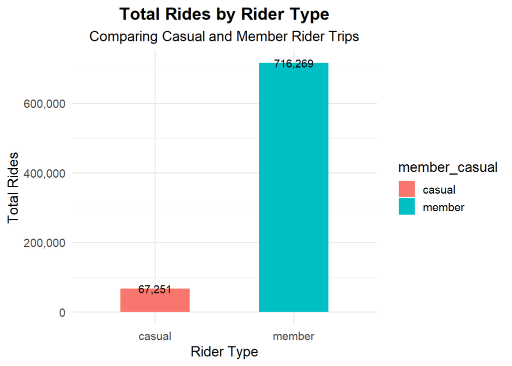

```r
ggplot(rider_summary, aes(x = member_casual, y = total_rides, fill = member_casual)) +
  geom_col(width = 0.5) +
  geom_text(aes(label = scales::comma(total_rides))) +
    labs(
    title = "Total Rides by Rider Type",
    subtitle = "Comparing Casual and Member Rider Trips",
    x = "Rider Type",
    y = "Total Rides"
  ) +
  scale_y_continuous(labels = scales::comma) +
  theme_minimal(base_size = 14) +
  theme(
    plot.title = element_text(hjust = 0.5, face = "bold"),
    plot.subtitle = element_text(hjust = 0.5),
  )
```

#### Summary

- Members took more than 10 times the number of rides as casual riders (716,269 vs. 67,251). This shows that annual members are the company’s most consistent and frequent users. This reinforces the idea that focusing on member retention and conversion is the right business strategy.
- Casual riders take much longer trips on average. Their average ride length is over 36 minutes, which is more than three times longer than a member’s average trip of about 11 minutes.

#### 2. Analyzed Average Ride Length(minutes) and ridership by day of the week

```r
ridership_summary_by_day <- all_trips_clean %>%
  group_by(member_casual, day_of_week) %>%
  summarise(
    total_rides = n(),
    avg_ride_length_minutes = mean(ride_length_mins, na.rm = TRUE),
    .groups = 'drop'
  )
print(ridership_summary_by_day)
```

```
## # A tibble: 14 × 4
##    member_casual day_of_week total_rides avg_ride_length_minutes
##    <chr>         <ord>             <int>                   <dbl>
##  1 casual        Sun               18485                    39.4
##  2 casual        Mon                5544                    31.8
##  3 casual        Tue                7250                    33.3
##  4 casual        Wed                7607                    38.8
##  5 casual        Thu                7071                    33.1
##  6 casual        Fri                7926                    33.2
##  7 casual        Sat               13368                    36.4
##  8 member        Sun               59688                    12.9
##  9 member        Mon              109836                    11.0
## 10 member        Tue              127338                    11.2
## 11 member        Wed              121283                    11.1
## 12 member        Thu              124545                    11.0
## 13 member        Fri              114563                    10.9
## 14 member        Sat               59016                    12.2
```

#### Visualize Ridership by the Day of the Week Analysis using a bar chart

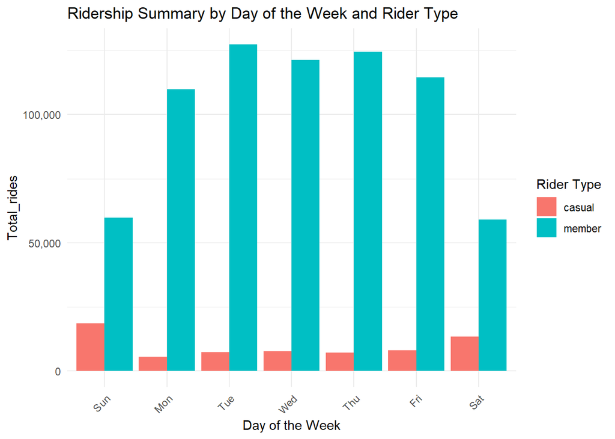

```r
ggplot(ridership_summary_by_day) + aes(x = day_of_week, y = total_rides, fill = member_casual) +
  geom_bar(stat = "identity", position = "dodge") +
  labs(
    title = "Ridership Summary by Day of the Week and Rider Type",
    x = "Day of the Week",
    y = "Total_rides",
    fill = "Rider Type") +
  scale_y_continuous(labels = scales::comma) +
  theme_minimal() +
  theme(axis.text.x = element_text(angle = 45, hjust = 1))
```

#### Average Ride Length By Day of the Week

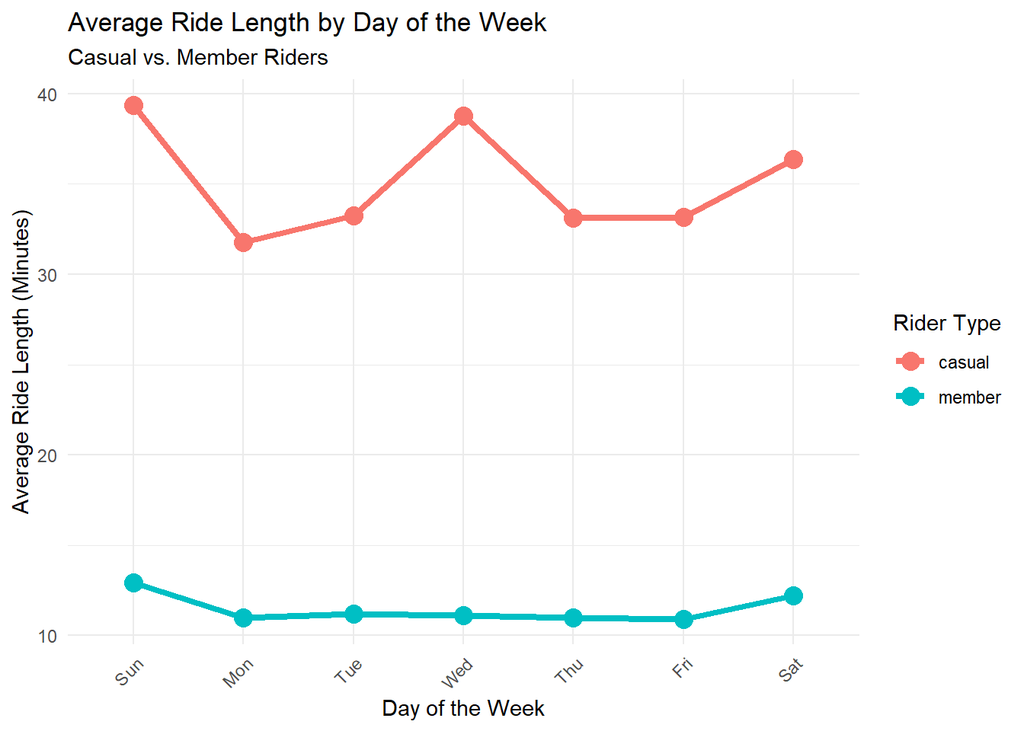

```r
ggplot(ridership_summary_by_day) + aes(x = day_of_week, y = avg_ride_length_minutes, group = member_casual, color = member_casual) +
  geom_line(linewidth = 1.5) +
  geom_point(shape = "circle", size = 4) +
  labs(
    title = "Average Ride Length by Day of the Week",
    subtitle = "Casual vs. Member Riders",
    x = "Day of the Week",
    y = "Average Ride Length (Minutes)",
    color = "Rider Type"
  ) +
  scale_y_continuous(labels = scales::comma) +
  theme_minimal() +
  theme(axis.text.x = element_text(angle = 45, hjust = 1))
```

#### 3. Calculate Total Rides and Average Ride Length by Month

```r
monthly_summary <- all_trips_clean %>%
group_by(member_casual, month) %>%
  summarise(
    total_rides = n(),
    avg_ride_length_mins = mean(ride_length_mins, na.rm = TRUE),
    .groups = 'drop')

print(monthly_summary)
```

```
## # A tibble: 6 × 4
##   member_casual month total_rides avg_ride_length_mins
##   <chr>         <ord>       <int>                <dbl>
## 1 casual        Jan         12241                 33.7
## 2 casual        Feb         14804                 35.4
## 3 casual        Mar         40206                 37.0
## 4 member        Jan        233422                 10.9
## 5 member        Feb        218863                 10.9
## 6 member        Mar        263984                 11.9
```

#### Summary

- The number of rides for casual riders increases significantly as the weather improves. It more than triples from January (12,241 rides) to March (40,206 rides). This indicates that as the weather begins to warm up in March, casual riders are much more likely to use the service for outdoor, recreational activities.
- Members consistently take a much higher volume of rides compared to casual riders each month. While their ridership also increases from January (233,422 rides) to March (263,984 rides) it is more stable and consistent. This supports the idea that members use the bikes for consistent, year-round transportation, with a moderate increase in numbers as the weather becomes more favorable.

#### Visualize the Monthly Trends

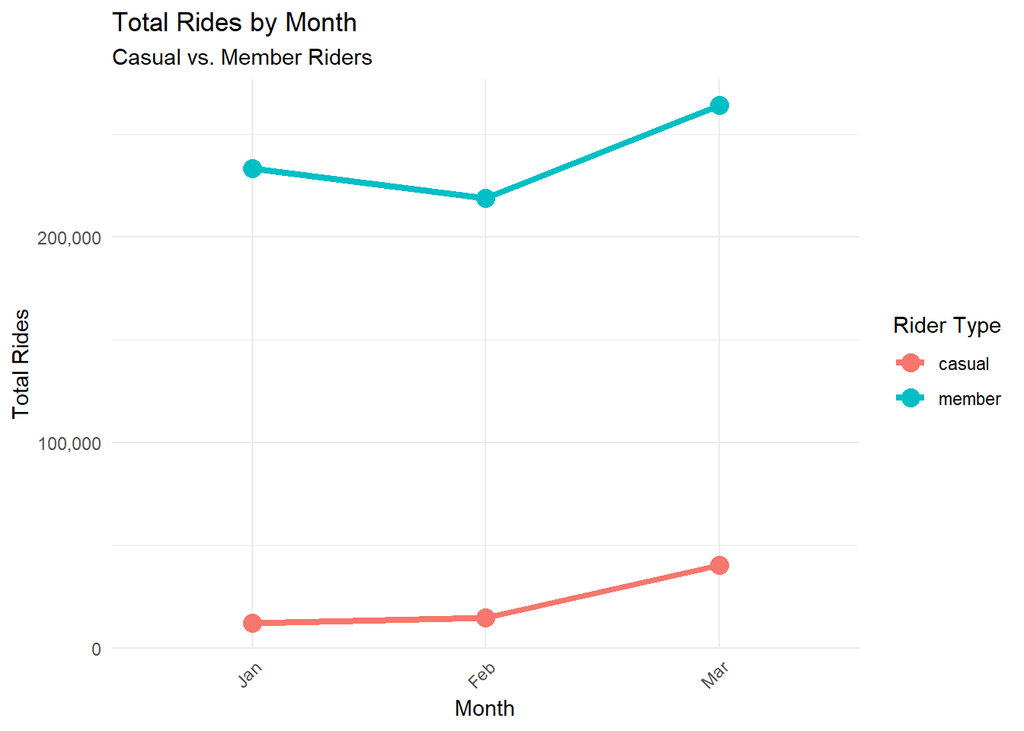

```r
ggplot(monthly_summary) + aes(x = month, y = total_rides, group = member_casual, colour = member_casual) +
  geom_line(linewidth = 1.5) +
  geom_point(size = 4, shape = "circle") +
  labs(
    title = "Total Rides by Month",
    subtitle = "Casual vs. Member Riders",
    x = "Month",
    y = "Total Rides",
    color = "Rider Type"
  ) +
  scale_y_continuous(labels = scales::comma) +
  theme_minimal() +
  theme(axis.text.x = element_text(angle = 45, hjust = 1))
```

#### Average ride length by month

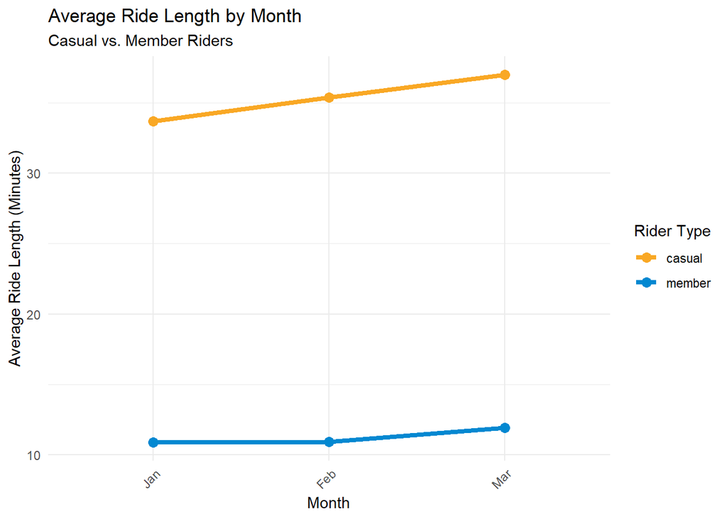

```r
# Plot 2: Average Ride Length by Month
ggplot(monthly_summary, aes(x = month, y = avg_ride_length_mins, group = member_casual, color = member_casual)) +
  geom_line(linewidth = 1.5) +
  geom_point(size = 3) +
  labs(
    title = "Average Ride Length by Month",
    subtitle = "Casual vs. Member Riders",
    x = "Month",
    y = "Average Ride Length (Minutes)",
    color = "Rider Type"
  ) +
  scale_y_continuous(labels = scales::comma) +
  scale_color_manual(values = c("casual" = "#F9A825", "member" = "#0288D1")) +
  theme_minimal() +
  theme(axis.text.x = element_text(angle = 45, hjust = 1))
```

#### Summary

- The average ride length for casual riders remains consistently high, ranging from 33.68 minutes in January to 36.96 minutes in March. This reinforces the hypothesis that casual riders use the bikes for extended, leisurely trips, regardless of the month.

Members: Members maintain a very short and consistent average ride length, at around 11 minutes each month. This indicates their use is primarily for quick, functional trips like commuting or errands, a behavior that remains stable throughout the quarter.

#### 4. Count and Rank Popular Start Stations for rider types

```r
top_start_stations <- all_trips_clean %>%
  group_by(member_casual, start_station_name) %>%
  count(name = "total_rides") %>%
  ungroup() %>%
  group_by(member_casual) %>%
  slice_max(order_by = total_rides, n = 10) %>%
  ungroup() %>%
  arrange(member_casual)


print(top_start_stations)
```

```
## # A tibble: 20 × 3
##    member_casual start_station_name           total_rides
##    <chr>         <chr>                              <int>
##  1 casual        Streeter Dr & Grand Ave             2728
##  2 casual        Lake Shore Dr & Monroe St           2714
##  3 casual        Shedd Aquarium                      1821
##  4 casual        Millennium Park                     1398
##  5 casual        Michigan Ave & Oak St               1012
##  6 casual        Michigan Ave & Washington St         832
##  7 casual        Dusable Harbor                       829
##  8 casual        Adler Planetarium                    823
##  9 casual        Theater on the Lake                  791
## 10 casual        Lake Shore Dr & North Blvd           600
## 11 member        Canal St & Adams St                13748
## 12 member        Clinton St & Washington Blvd       13387
## 13 member        Clinton St & Madison St            12834
## 14 member        Kingsbury St & Kinzie St            8681
## 15 member        Columbus Dr & Randolph St           8464
## 16 member        Canal St & Madison St               7858
## 17 member        Franklin St & Monroe St             6971
## 18 member        Michigan Ave & Washington St        6669
## 19 member        Larrabee St & Kingsbury St          6442
## 20 member        Clinton St & Lake St                6418
```

- The most popular stations for casual riders are concentrated around major tourist attractions and recreational areas in Chicago. This include; Streeter Dr & Grand Ave, Lake Shore Dr & Monroe St, Shedd Aquarium, Millennium Park, Adler Planetarium etc.
- These locations are popular leisure destinations, suggesting that casual riders are likely tourists or locals using the bikes for sightseeing or recreational activities along the lakefront and in downtown parks.
- In contrast, the top start stations for members are located in central business districts and near major train stations and office buildings. These include; Canal St & Adams St, clinton St & Washington Blvd, Clinton St & Madison St, Franklin St & Monroe St etc.
- These stations are common transit hubs, indicating that members primarily use the bikes for commuting and short-distance travel.
- Michigan Ave & Washington St, appears on both lists. This suggests it is a central hub that serves both commuters (members) and tourists (casual riders).

# Recommendations

1. Casual riders tend to use the service for leisure and are most active during the weekend and warmer months. This provides the best opportunity to convert them to members by placing digital ads at high-traffic stations near parks and other popular spots. The ads should clearly demonstrate how a membership is a better value than buying multiple day passes.
2. Introduce a low-cost, short-term pass that acts as a stepping stone i.e. monthly or quartely passes offering unlimited rides, with a built-in incentive to upgrade. By offering a discount on annual membership after a certain number of uses, this strategy lowers the entry barrier and smoothly converts casual riders into annual members.
3. To convert casual riders to annual members, shift their perception of Cyclistic from a leisure tool to a daily utility. Launch a campaign that highlights how members use the bikes for cost-effective commutes and errands.